# A Bayesian SEIR model in JAGS

### Introduction

Following on from the file `Bayes_SIR_JAGS` here I fit the SEIR model to the Irish data set using the John Hopkins data. The notation and meaning of the file is the same as in that file.

### JAGS model

Below is the code for the JAGS model:

```r
jags_code = '
model {
  # Likelihood
  for (t in 1:T) {
    N_E_I[t] ~ dbinom(p_E_I, E[t])
    N_I_R[t] ~ dbinom(p_I_R, I[t])
    # These are imputed:
    N_S_E[t] ~ dbinom(p_S_E[t], S[t])
    R_0[t] <- (beta[t]/gamma)*(S[t]/N)
  }

  # These are the known time evolution steps:
  for(t in 2:T) {
    S[t] <- S[t-1] - N_S_E[t-1]
    E[t] <- E[t-1] + N_S_E[t-1] - N_E_I[t-1]
    I[t] <- I[t-1] + N_E_I[t-1] - N_I_R[t-1]
    R[t] <- N - S[t] - E[t] - I[t]
  }

  # Need a value for S[1], E[1], and I[1]
  I[1] <- I_start # Assume the number of people infected on day 1 is the same as those transitioning from E to I
  R[1] <- R_start # As above but for removed
  E[1] <- E_start
  S[1] <- N - I[1] - E[1] - R[1] # Left over

  # This is the prior on p_S_E[t]
  for(t in 1:T) {
    p_S_E[t] <- 1 - exp( - beta[t] * I[t] / N )
  }

  # Sort out the change point
  for(t in 1:(t_star - 1)) {
    beta[t] <- beta_const
  }
  for (t in t_star:T) {
    beta[t] <- beta_const * exp( - q * (t - t_star))
  }

  # These are the priors on the other probabilities
  p_E_I <- 1 - exp( -rho )
  p_I_R <- 1 - exp( -gamma )

  # Now the prior on the hyper-parameters
  beta_const ~ dunif(0.6, 0.7) # Transmission rate
  rho <- 1/rho_inv
  rho_inv ~ dunif(1, 14) # Mean exposure time
  gamma <- 1/gamma_inv
  gamma_inv ~ dunif(1, 14) # Mean infection length
  q ~ dunif(0.0, 0.01) # Effect of intervention

  # Can now fit into the future
  for (t in (T+1):T_max) {

    # Transitions
    N_E_I[t] ~ dbinom(p_E_I, E[t])
    N_I_R[t] ~ dbinom(p_I_R, I[t])
    N_S_E[t] ~ dbinom(p_S_E[t], S[t])

    # R_0
    R_0[t] = (beta[t]/gamma)*(S[t]/N)

    # Compartment values
    S[t] <- S[t-1] - N_S_E[t-1]
    E[t] <- E[t-1] + N_S_E[t-1] - N_E_I[t-1]
    I[t] <- I[t-1] + N_E_I[t-1] - N_I_R[t-1]
    R[t] = N - S[t] - E[t] - I[t]

    # Probability values
    p_S_E[t] <- 1 - exp( - beta[t] * I[t] / N )
    beta[t] <- beta_const * exp( - q * (t - t_star))
  }
}
'
```

### Fit to Irish data

To fit the model to real data we need:

- The number of people infected on day $t$. We have a (poor) estimate of this
- The number of people recovered on day $t$. We have a (very poor) estimate of this
- Good estimates of the values of the transmission rate, the mean length of time of exposure, and the mean length of time of infection
- Good estimates of the starting values of the number of exposed and infected people. I’m not sure we have either of these.

Because the John Hopkins data includes the recovery data too I will use that combined with deaths to model removed values. Lots of these values will be wrong or quite wildly different from the truth.

Load in the John Hopkins data and select Ireland:

```r
library(tidycovid19)
library(dplyr)
jh_data = download_jhu_csse_covid19_data(silent = TRUE,
                                         cached = TRUE) %>%
  filter(country == "Ireland",
         date > as.Date("2020-02-29")) %>%
  rename(cum_cases = confirmed) %>%
  mutate(cum_removed = recovered + deaths,
         cases = c(cum_cases[1], diff(cum_cases)),
         removed = c(cum_removed[1], diff(cum_removed)),
         days_since_29_2 = date - as.Date("2020-02-29"))
```

I’m going to assume that the population of Ireland is 4.5 million and that the time of the intervention was March 12th (which was 12 days after 29/2) when all schools were closed, though there was a further lockdown on March 24th.

Now fit the jags model:

```r
N_future = 100 # Forecast 100 days into the future
T = nrow(jh_data)
t_star = 12
T_max = T + N_future
jags_data = list(N = 4500000,
                 T = T,
                 T_max = T_max,
                 t_star = t_star,
                 I_start = jh_data$cases[1],
                 E_start = 100,
                 R_start = jh_data$removed[1],
                 N_E_I = c(jh_data$cases, rep(NA, N_future)),
                 N_I_R = c(jh_data$removed, rep(NA, N_future)))

jags_run = jags(data = jags_data,
                parameters.to.save = c("gamma_inv", "q", "beta",
                                       "rho_inv", "beta_const",
                                       "S", "E", "I", "R", "R_0"),
                model.file = textConnection(jags_code))
```

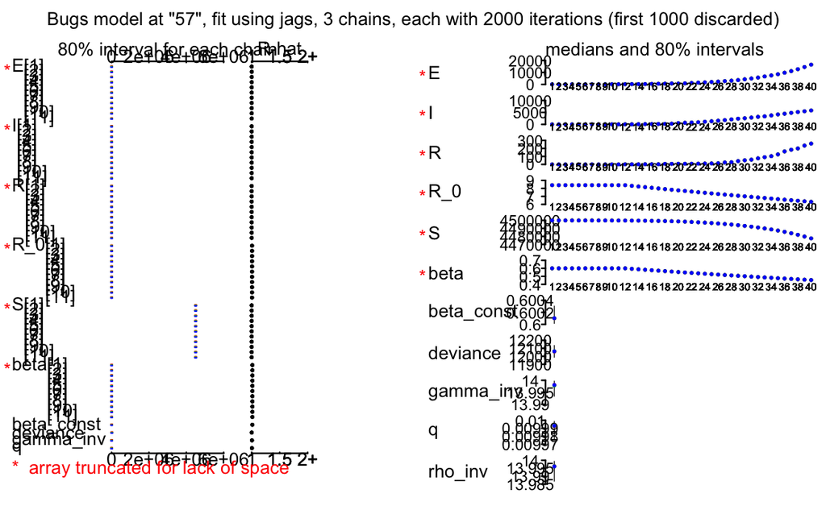

```r
plot(jags_run)
```

Plot the output

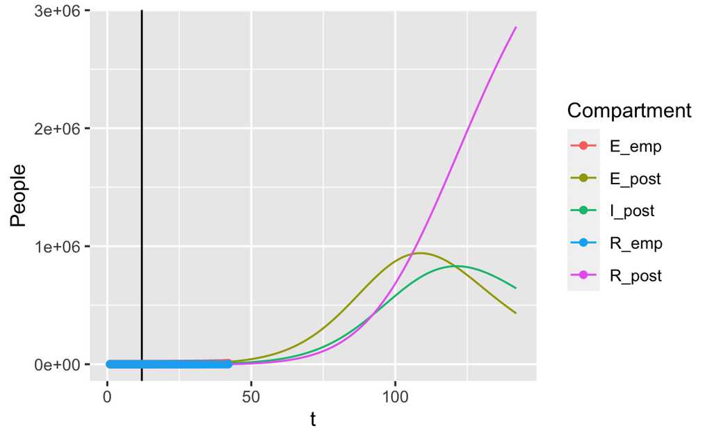

```r
S_post = jags_run$BUGSoutput$median$S
E_post = jags_run$BUGSoutput$median$E
I_post = jags_run$BUGSoutput$median$I
R_post = jags_run$BUGSoutput$median$R

tibble_emp = tibble(t = 1:T,
       E_emp = jh_data$cum_cases,
       R_emp = jh_data$cum_removed) %>%
  pivot_longer(names_to = 'Compartment', values_to = 'People', -t)
tibble(t = 1:T_max,
       E_post, I_post, R_post) %>%
  pivot_longer(names_to = 'Compartment', values_to = 'People', -t) %>%
  ggplot(aes(x = t, y = People, colour = Compartment)) +
  geom_vline(xintercept = t_star) +
  geom_line() +
  geom_point(data = tibble_emp)
```

Plot $R_0(t)$:

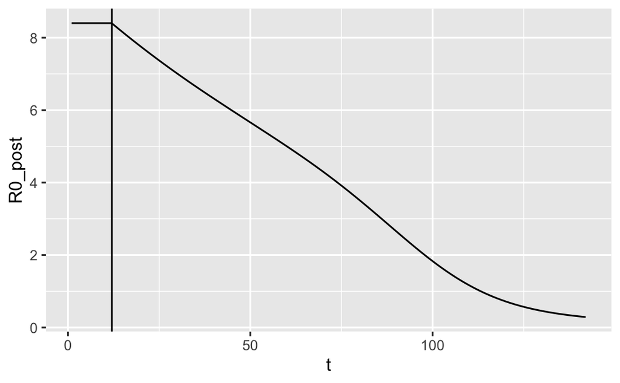

```r
R0_post = jags_run$BUGSoutput$median$R_0
tibble(t = 1:T_max,
       R0_post = R0_post) %>%
  ggplot(aes(x = t, y = R0_post)) +
  geom_vline(xintercept = t_star) +
  geom_line()
```